# Zestaw zadań nr 2

Wiktor Kostera

2023-10-24

## Zadanie 1

Pierwsze zadanie miało na celu zapoznanie się z podstawowymi funkcjami z rodziny `apply()`. Na samym początku należało stworzyć zgodnie z instrukcją listę `lista2` i na nie zastosować funkcję `lapply()` w celu obliczenia podstawowych statystyk opisowych tj. `mean()`, `sd()` oraz `quantile`.

```r
lista2 <- list(dane1 = c(NA, 1:10),
               dane2 = c(-5:5, NA))
lista2
```

```
## $dane1
##  [1] NA  1  2  3  4  5  6  7  8  9 10
##
## $dane2
##  [1] -5 -4 -3 -2 -1  0  1  2  3  4  5 NA
```

```r
lapply(lista2, mean, na.rm = TRUE)
```

```
## $dane1
## [1] 5.5
##
## $dane2
## [1] 0
```

```r
lapply(lista2, sd, na.rm = TRUE)
```

```
## $dane1
## [1] 3.02765
##
## $dane2
## [1] 3.316625
```

```r
lapply(lista2, quantile, na.rm = TRUE)
```

```
## $dane1
##    0%   25%   50%   75%  100%
##  1.00  3.25  5.50  7.75 10.00
##
## $dane2
##   0%  25%  50%  75% 100%
## -5.0 -2.5  0.0  2.5  5.0
```

## Zadanie 2

Kolejne zadanie polegało na wykonaniu kilku poleceń przy użyciu funkcji `sapply()`. W tym celu należało stworzyć zgodnie z instrukcją listę `lista4`, a następnie obliczyć `min()` oraz `max()`.

```r
lista4 <- list(dane1 = 20:1,
               dane2 = 1:10,
               dane3 = 1:5)
lista4
```

```
## $dane1
##  [1] 20 19 18 17 16 15 14 13 12 11 10  9  8  7  6  5  4  3  2  1
##
## $dane2
##  [1]  1  2  3  4  5  6  7  8  9 10
##
## $dane3
## [1] 1 2 3 4 5
```

```r
sapply(lista4, min)
```

```
## dane1 dane2 dane3
##     1     1     1
```

```r
sapply(lista4, max)
```

```
## dane1 dane2 dane3
##    20    10     5
```

Jak można zauważyć funkcja `lapply()` zawsze zwraca listę podczas gdy `sapply()` upraszcza formę do jak najbardziej jednorodnej co nie zawsze jest listą.

Ostatnim elementem zadania było zbudowanie funkcji mierzącej współczynnik zmienności. W tym celu można wykorzystać funkcję `sapply()`. Następnie wywołuję ją dla listy `lista4`.

```r
wsp_zmiennosci <- function(lista4) {
  wsp <- sapply(lista4, sd)/sapply(lista4, mean)
  wsp
}

wsp_zmiennosci(lista4)
```

```
##     dane1     dane2     dane3
## 0.5634362 0.5504819 0.5270463
```

## Zadanie 3

Celem następnego zadania było wyjaśnienie w jaki sposób działa funkcja `apply()`. W tym celu tworzę macierz składającą się z 30 elementów.

```r
macierz1 <- matrix(1:30, nrow = 5, ncol = 6)
macierz1
```

```
##      [,1] [,2] [,3] [,4] [,5] [,6]
## [1,]    1    6   11   16   21   26
## [2,]    2    7   12   17   22   27
## [3,]    3    8   13   18   23   28
## [4,]    4    9   14   19   24   29
## [5,]    5   10   15   20   25   30
```

Funkcja `apply()` w przeciwieństwie do pozostałych z rodziny, stosowana jest do wykonywania konkretnej funkcji do wartości tablicy lub macierzy odpowiednio na wierszach lub kolumnach. Argument `MARGIN` decyduje o tym, dla jakiej części zestawu chcemy wykonać funkcję (1 dla wierszy, 2 dla kolumn). Poniższe przykłady pokazują zastosowanie w jednym jak i drugim przypadku.

```r
apply(macierz1, MARGIN = 1, mean)
```

```
## [1] 13.5 14.5 15.5 16.5 17.5
```

```r
apply(macierz1, MARGIN = 2, sum)
```

```
## [1]  15  40  65  90 115 140
```

## Zadanie 4

Zadanie 4. koncentruje się na zapoznaniu z funkcją `tapply()`. W tym celu należało wykonać następujące polecenia:

1. Obejrzeć zestaw mtcars (on również jest jednym ze zbiorów w pakiecie datasets).

```r
mtcars
```

|  | mpg | cyl | disp | hp | drat | wt | qsec | vs | am | gear | carb |
| --- | --- | --- | --- | --- | --- | --- | --- | --- | --- | --- | --- |
| Mazda RX4 | 21.0 | 6 | 160.0 | 110 | 3.90 | 2.620 | 16.46 | 0 | 1 | 4 | 4 |
| Mazda RX4 Wag | 21.0 | 6 | 160.0 | 110 | 3.90 | 2.875 | 17.02 | 0 | 1 | 4 | 4 |
| Datsun 710 | 22.8 | 4 | 108.0 | 93 | 3.85 | 2.320 | 18.61 | 1 | 1 | 4 | 1 |
| Hornet 4 Drive | 21.4 | 6 | 258.0 | 110 | 3.08 | 3.215 | 19.44 | 1 | 0 | 3 | 1 |
| Hornet Sportabout | 18.7 | 8 | 360.0 | 175 | 3.15 | 3.440 | 17.02 | 0 | 0 | 3 | 2 |
| Valiant | 18.1 | 6 | 225.0 | 105 | 2.76 | 3.460 | 20.22 | 1 | 0 | 3 | 1 |
| Duster 360 | 14.3 | 8 | 360.0 | 245 | 3.21 | 3.570 | 15.84 | 0 | 0 | 3 | 4 |
| Merc 240D | 24.4 | 4 | 146.7 | 62 | 3.69 | 3.190 | 20.00 | 1 | 0 | 4 | 2 |
| Merc 230 | 22.8 | 4 | 140.8 | 95 | 3.92 | 3.150 | 22.90 | 1 | 0 | 4 | 2 |
| Merc 280 | 19.2 | 6 | 167.6 | 123 | 3.92 | 3.440 | 18.30 | 1 | 0 | 4 | 4 |

[output cut: 22 more lines]

2. Z wykorzystaniem odpowiedniej funkcji z rozdziny `apply()`, uzyskać informację o przeciętnym spalaniu w zależności od liczby cylindów.

```r
tapply(X = mtcars$mpg, INDEX = mtcars$cyl, FUN = mean)
```

```
##        4        6        8
## 26.66364 19.74286 15.10000
```

3. Rozszerzyć analizę w/w problemu i wyświetlić podstawowe statystyki opisowe (funkcja `summary()`).

```r
summary(mtcars)
```

```
##       mpg             cyl             disp             hp
##  Min.   :10.40   Min.   :4.000   Min.   : 71.1   Min.   : 52.0
##  1st Qu.:15.43   1st Qu.:4.000   1st Qu.:120.8   1st Qu.: 96.5
##  Median :19.20   Median :6.000   Median :196.3   Median :123.0
##  Mean   :20.09   Mean   :6.188   Mean   :230.7   Mean   :146.7
##  3rd Qu.:22.80   3rd Qu.:8.000   3rd Qu.:326.0   3rd Qu.:180.0
##  Max.   :33.90   Max.   :8.000   Max.   :472.0   Max.   :335.0
##       drat             wt             qsec             vs
##  Min.   :2.760   Min.   :1.513   Min.   :14.50   Min.   :0.0000
##  1st Qu.:3.080   1st Qu.:2.581   1st Qu.:16.89   1st Qu.:0.0000
##  Median :3.695   Median :3.325   Median :17.71   Median :0.0000
##  Mean   :3.597   Mean   :3.217   Mean   :17.85   Mean   :0.4375
##  3rd Qu.:3.920   3rd Qu.:3.610   3rd Qu.:18.90   3rd Qu.:1.0000
##  Max.   :4.930   Max.   :5.424   Max.   :22.90   Max.   :1.0000
##        am              gear            carb
##  Min.   :0.0000   Min.   :3.000   Min.   :1.000
##  1st Qu.:0.0000   1st Qu.:3.000   1st Qu.:2.000
##  Median :0.0000   Median :4.000   Median :2.000
##  Mean   :0.4062   Mean   :3.688   Mean   :2.812
##  3rd Qu.:1.0000   3rd Qu.:4.000   3rd Qu.:4.000
##  Max.   :1.0000   Max.   :5.000   Max.   :8.000
```

## Zadanie 5

Kolejne zadanie wymagało zapoznania się z zestawym danych `anscombe` z pakietu `dataset` oraz `fgl` z pakietu `MASS`.

```r
anscombe
```

| x1 | x2 | x3 | x4 | y1 | y2 | y3 | y4 |
| --- | --- | --- | --- | --- | --- | --- | --- |
| 10 | 10 | 10 | 8 | 8.04 | 9.14 | 7.46 | 6.58 |
| 8 | 8 | 8 | 8 | 6.95 | 8.14 | 6.77 | 5.76 |
| 13 | 13 | 13 | 8 | 7.58 | 8.74 | 12.74 | 7.71 |
| 9 | 9 | 9 | 8 | 8.81 | 8.77 | 7.11 | 8.84 |
| 11 | 11 | 11 | 8 | 8.33 | 9.26 | 7.81 | 8.47 |
| 14 | 14 | 14 | 8 | 9.96 | 8.10 | 8.84 | 7.04 |
| 6 | 6 | 6 | 8 | 7.24 | 6.13 | 6.08 | 5.25 |
| 4 | 4 | 4 | 19 | 4.26 | 3.10 | 5.39 | 12.50 |
| 12 | 12 | 12 | 8 | 10.84 | 9.13 | 8.15 | 5.56 |
| 7 | 7 | 7 | 8 | 4.82 | 7.26 | 6.42 | 7.91 |

[output cut: 1 more lines]

```r
library(MASS)
fgl
```

|  | RI | Na | Mg | Al | Si | K | Ca | Ba | Fe | type |
| --- | --- | --- | --- | --- | --- | --- | --- | --- | --- | --- |
| 1 | 3.01 | 13.64 | 4.49 | 1.10 | 71.78 | 0.06 | 8.75 | 0.00 | 0.00 | WinF |
| 2 | -0.39 | 13.89 | 3.60 | 1.36 | 72.73 | 0.48 | 7.83 | 0.00 | 0.00 | WinF |
| 3 | -1.82 | 13.53 | 3.55 | 1.54 | 72.99 | 0.39 | 7.78 | 0.00 | 0.00 | WinF |
| 4 | -0.34 | 13.21 | 3.69 | 1.29 | 72.61 | 0.57 | 8.22 | 0.00 | 0.00 | WinF |
| 5 | -0.58 | 13.27 | 3.62 | 1.24 | 73.08 | 0.55 | 8.07 | 0.00 | 0.00 | WinF |
| 6 | -2.04 | 12.79 | 3.61 | 1.62 | 72.97 | 0.64 | 8.07 | 0.00 | 0.26 | WinF |
| 7 | -0.57 | 13.30 | 3.60 | 1.14 | 73.09 | 0.58 | 8.17 | 0.00 | 0.00 | WinF |
| 8 | -0.44 | 13.15 | 3.61 | 1.05 | 73.24 | 0.57 | 8.24 | 0.00 | 0.00 | WinF |
| 9 | 1.18 | 14.04 | 3.58 | 1.37 | 72.08 | 0.56 | 8.30 | 0.00 | 0.00 | WinF |
| 10 | -0.45 | 13.00 | 3.60 | 1.36 | 72.99 | 0.57 | 8.40 | 0.00 | 0.11 | WinF |

[output cut: 204 more lines]

Ramka danych `fgl` zawiera informacje dotyczące fragmentow szkła zebranych w trakcie prac kryminalistycznych. Z kolei ramka danych `anscombe` składa się z czterech zbiorów danych, które mają niemal identyczne proste statystyki opisowe, lecz mają różne rozkłady co najlepiej prezentują odpowiednie wykresy

Kolejnym elementem zadania było wykonanie następujących poleceń:

1. Użyć funkcji z rodziny `apply()` do wyznaczenia średnich we wszystkich kolumnach wybranej ramki danych.

```r
sapply(anscombe, mean)
```

```
##       x1       x2       x3       x4       y1       y2       y3       y4
## 9.000000 9.000000 9.000000 9.000000 7.500909 7.500909 7.500000 7.500909
```

2. Użyj funkcji `str()` do sprawdzenia, które kolumny są numeryczne, i powtórzyć zad. 1 tylko do tych kolumn.

```r
str(anscombe)
```

```
## 'data.frame':    11 obs. of  8 variables:
##  $ x1: num  10 8 13 9 11 14 6 4 12 7 ...
##  $ x2: num  10 8 13 9 11 14 6 4 12 7 ...
##  $ x3: num  10 8 13 9 11 14 6 4 12 7 ...
##  $ x4: num  8 8 8 8 8 8 8 19 8 8 ...
##  $ y1: num  8.04 6.95 7.58 8.81 8.33 ...
##  $ y2: num  9.14 8.14 8.74 8.77 9.26 8.1 6.13 3.1 9.13 7.26 ...
##  $ y3: num  7.46 6.77 12.74 7.11 7.81 ...
##  $ y4: num  6.58 5.76 7.71 8.84 8.47 7.04 5.25 12.5 5.56 7.91 ...
```

Wszystkie kolumny są numeryczne, zatem dla każdej z nich możemy policzyć `sd()` oraz `quantile()`.

```r
lapply(anscombe, sd, na.rm = TRUE)
```

```
## $x1
## [1] 3.316625
##
## $x2
## [1] 3.316625
##
## $x3
## [1] 3.316625
##
## $x4
## [1] 3.316625
##
## $y1
## [1] 2.031568
##
## $y2
## [1] 2.031657
##
## $y3
## [1] 2.030424
##
## $y4
## [1] 2.030579
```

```r
lapply(anscombe, quantile, na.rm = TRUE)
```

```
## $x1
##   0%  25%  50%  75% 100%
##  4.0  6.5  9.0 11.5 14.0
##
## $x2
##   0%  25%  50%  75% 100%
##  4.0  6.5  9.0 11.5 14.0
##
## $x3
##   0%  25%  50%  75% 100%
##  4.0  6.5  9.0 11.5 14.0
##
## $x4
##   0%  25%  50%  75% 100%
##    8    8    8    8   19
##
## $y1
##     0%    25%    50%    75%   100%
##  4.260  6.315  7.580  8.570 10.840
##
## $y2
##    0%   25%   50%   75%  100%
## 3.100 6.695 8.140 8.950 9.260
##
## $y3
##    0%   25%   50%   75%  100%
##  5.39  6.25  7.11  7.98 12.74
##
## $y4
##    0%   25%   50%   75%  100%
##  5.25  6.17  7.04  8.19 12.50
```

3. Użyć funkcji z rodziny `apply()` do wyznaczenia mediany we wszystkich kolumnach iloścowych. Dla której zmiennej widzimy największą różnicę między średnią a medianą?

```r
apply(anscombe, 2, median)
```

```
##   x1   x2   x3   x4   y1   y2   y3   y4
## 9.00 9.00 9.00 8.00 7.58 8.14 7.11 7.04
```

```r
med_mean <- function(x) {
  roznica <- mean(x) - median(x)
  return(roznica)
}

roznice <- apply(anscombe, 2, med_mean)
roznice
```

```
##          x1          x2          x3          x4          y1          y2
##  0.00000000  0.00000000  0.00000000  1.00000000 -0.07909091 -0.63909091
##          y3          y4
##  0.39000000  0.46090909
```

4. Użyć funkcji z rodziny `apply()` do obliczenia odchylenia standardowego oraz współczynnika zmienności dla wszystkich kolumn ilościowych.

```r
apply(anscombe, 2, sd)
```

```
##       x1       x2       x3       x4       y1       y2       y3       y4
## 3.316625 3.316625 3.316625 3.316625 2.031568 2.031657 2.030424 2.030579
```

```r
wsp_zmien <- function(x) {
  wsp <- sd(x) * 100 / mean(x)
  return(wsp)
}
apply(anscombe, 2, wsp_zmien)
```

```
##       x1       x2       x3       x4       y1       y2       y3       y4
## 36.85139 36.85139 36.85139 36.85139 27.08429 27.08547 27.07231 27.07110
```

## Zadanie 6

Celem zadania szóstego było zapoznanie się z pakietami `tidyr`, `dplyr` oraz `gapminder`.

```r
library(tidyr)
library(dplyr)
library(gapminder)
```

Następnie w oparciu o zestaw danych `gapminder` należało wykonać następujące polecenia:

1. Proszę zmienić nazwy zmiennych, tj. zmienną year nazwać rok, a zmienną gdpperCap nazwać PKB.

```r
gapminder <- gapminder %>%
             rename(rok = year, PKB = gdpPercap)
gapminder
```

| country | continent | rok | lifeExp | pop | PKB |
| --- | --- | --- | --- | --- | --- |
| Afghanistan | Asia | 1952 | 28.80100 | 8425333 | 779.4453 |
| Afghanistan | Asia | 1957 | 30.33200 | 9240934 | 820.8530 |
| Afghanistan | Asia | 1962 | 31.99700 | 10267083 | 853.1007 |
| Afghanistan | Asia | 1967 | 34.02000 | 11537966 | 836.1971 |
| Afghanistan | Asia | 1972 | 36.08800 | 13079460 | 739.9811 |
| Afghanistan | Asia | 1977 | 38.43800 | 14880372 | 786.1134 |
| Afghanistan | Asia | 1982 | 39.85400 | 12881816 | 978.0114 |
| Afghanistan | Asia | 1987 | 40.82200 | 13867957 | 852.3959 |
| Afghanistan | Asia | 1992 | 41.67400 | 16317921 | 649.3414 |
| Afghanistan | Asia | 1997 | 41.76300 | 22227415 | 635.3414 |

[output cut: 1694 more lines]

2. Proszę zmienić wartości zmiennej pop tak, aby ludność była przedstawiona w milionach osób.

```r
gapminder <- gapminder %>%
             mutate(pop = pop / 1000000)
gapminder
```

| country | continent | rok | lifeExp | pop | PKB |
| --- | --- | --- | --- | --- | --- |
| Afghanistan | Asia | 1952 | 28.80100 | 8.425333 | 779.4453 |
| Afghanistan | Asia | 1957 | 30.33200 | 9.240934 | 820.8530 |
| Afghanistan | Asia | 1962 | 31.99700 | 10.267083 | 853.1007 |
| Afghanistan | Asia | 1967 | 34.02000 | 11.537966 | 836.1971 |
| Afghanistan | Asia | 1972 | 36.08800 | 13.079460 | 739.9811 |
| Afghanistan | Asia | 1977 | 38.43800 | 14.880372 | 786.1134 |
| Afghanistan | Asia | 1982 | 39.85400 | 12.881816 | 978.0114 |
| Afghanistan | Asia | 1987 | 40.82200 | 13.867957 | 852.3959 |
| Afghanistan | Asia | 1992 | 41.67400 | 16.317921 | 649.3414 |
| Afghanistan | Asia | 1997 | 41.76300 | 22.227415 | 635.3414 |

[output cut: 1694 more lines]

3. Wyświetlić wszystkie kraje afrykańskie, które w roku 1957 miały PKB większe niż 12000$ A czy jesteś w stanie narysować wykres, który pokazuje ile tych krajów było w każdym roku badania?

Na samym początku wyświetlimy wszystkie kraje, o które jesteśmy pytani w poleceniu.

```r
kraje_1957 <- gapminder %>%
              filter(continent == "Africa", rok == 1957, PKB > 12000)
kraje_1957
```

| country | continent | rok | lifeExp | pop | PKB |
| --- | --- | --- | --- | --- | --- |

Teraz przechodzimy do przygotowania danych potrzebnych do sporządzenia wykresu.

```r
wykres <- gapminder %>%
          filter(continent == "Africa", PKB > 12000) %>%
          group_by(rok) %>%
          summarize(ilosc_krajow = n())
wykres
```

| rok | ilosc_krajow |
| --- | --- |
| 1967 | 1 |
| 1972 | 1 |
| 1977 | 2 |
| 1982 | 2 |
| 1992 | 1 |
| 1997 | 1 |
| 2002 | 1 |
| 2007 | 4 |

Na samym końcu tworzymy wykres.

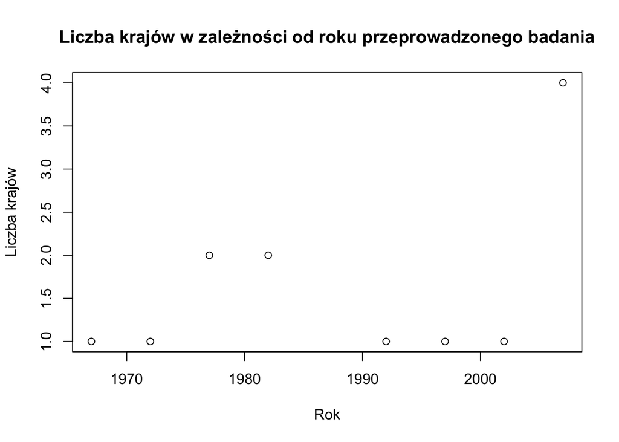

```r
plot(wykres,
     type = 'p',
     ylab = "Liczba krajów",
     xlab = "Rok",
     main = "Liczba krajów w zależności od roku przeprowadzonego badania")
```

4. Które kraje spoza Afryki w roku 1962 miały PKB mniejsze od 750$?

```r
spoza_afryki <- gapminder %>%
                filter(continent != "Africa", rok == 1962, PKB < 750) %>%
                select(country)
spoza_afryki
```

| country |
| --- |
| Bangladesh |
| Cambodia |
| China |
| India |
| Myanmar |
| Nepal |

5. Na przykładzie lat 1952, 1977 i 2002 sprawdzić, ile wynosiła przeciętna długość życia w Polsce. W których krajach obu Ameryk była ona większa? Czy na podstawie tych informacji, możesz spróbować wyciągnąć jakieś wnioski?

Na samym początku sprawdźmy ile wynosi przeciętna długość życia w Polsce w oparciu o podane lata.

```r
dl_polska <- gapminder %>%
             filter(country == "Poland", rok == 1952 | rok == 1977 | rok == 2002) %>%
             group_by(country) %>%
             summarize(srednia_dlugosc_zycia = mean(lifeExp))
dl_polska
```

| country | srednia_dlugosc_zycia |
| --- | --- |
| Poland | 68.88333 |

Jak widać średnia długość wynosi 68,9.

Przechodzimy teraz do przygotowania podobnego zestawu danych dla krajów z Ameryki.

```r
dl_ameryki <- gapminder %>%
              filter(continent == "Americas", rok == 1952 | rok == 1977 | rok == 2002) %>%
              group_by(country) %>%
              summarize(srednia_dlugosc_zycia = mean(lifeExp)) %>%
              print(n = Inf)
```

```
## # A tibble: 25 × 2
##    country             srednia_dlugosc_zycia
##    <fct>                               <dbl>
##  1 Argentina                            68.4
##  2 Bolivia                              51.4
##  3 Brazil                               61.1
##  4 Canada                               74.2
##  5 Chile                                66.6
##  6 Colombia                             62.1
##  7 Costa Rica                           68.7
##  8 Cuba                                 69.7
##  9 Dominican Republic                   59.5
## 10 Ecuador                              61.3
## 11 El Salvador                          57.6
## 12 Guatemala                            55.7
## 13 Haiti                                48.5
## 14 Honduras                             56.0
## 15 Jamaica                              66.9
## 16 Mexico                               63.6
## 17 Nicaragua                            56.9
## 18 Panama                               66.2
## 19 Paraguay                             66.6
## 20 Peru                                 57.4
## 21 Puerto Rico                          71.8
## 22 Trinidad and Tobago                  65.5
## 23 United States                        73.0
## 24 Uruguay                              70.3
## 25 Venezuela                            65.1
```

Na samym końcu wyświetlamy kraje z Ameryk, których średnia długość życia w oparciu o lata 1952, 1977 oraz 2002 jest dłuższa niż w Polsce.

```r
roznica_dl <- dl_ameryki %>%
              filter(srednia_dlugosc_zycia > 68.9)
roznica_dl
```

| country | srednia_dlugosc_zycia |
| --- | --- |
| Canada | 74.24333 |
| Cuba | 69.74267 |
| Puerto Rico | 71.83267 |
| United States | 73.04333 |
| Uruguay | 70.28633 |

6. Wyznaczyć podstawowe statystyki opisowe dot. wielkości populacji na różnych kontynentach w roku 2007. Pamiętaj o wykorzystaniu funkcji group_by() i summarize().

```r
stat_2007 <- gapminder %>%
             filter(rok == 2007) %>%
             group_by(continent) %>%
             summarize(ŚREDNIA = mean(pop),
                       MEDIANA = median(pop),
                       ODCHYLENIE_SD = sd(pop),
                       MINIMUM = min(pop),
                       MAKSIMUM = max(pop))
stat_2007
```

| continent | ŚREDNIA | MEDIANA | ODCHYLENIE_SD | MINIMUM | MAKSIMUM |
| --- | --- | --- | --- | --- | --- |
| Africa | 17.87576 | 10.093310 | 24.91773 | 0.199579 | 135.03116 |
| Americas | 35.95485 | 9.319622 | 68.83378 | 1.056608 | 301.13995 |
| Asia | 115.51375 | 24.821286 | 289.67340 | 0.708573 | 1318.68310 |
| Europe | 19.53662 | 9.493598 | 23.62474 | 0.301931 | 82.40100 |
| Oceania | 12.27497 | 12.274974 | 11.53885 | 4.115771 | 20.43418 |

7. Wśród krajów o PKB niższym od 5000$ (rozważyć dane za rok 1977), wyznaczyć po trzy kraje z Afryki, Europy i Azji, w których spodziewana długość życia jest największa.

```r
trzy_kraje <- gapminder %>%
              filter(rok == 1977,
                     PKB <  5000,
                     continent == "Africa" | continent == "Europe" | continent == "Asia") %>%
              group_by(continent) %>%
              top_n(3, lifeExp) %>%
              arrange(continent, desc(lifeExp))
trzy_kraje
```

| country | continent | rok | lifeExp | pop | PKB |
| --- | --- | --- | --- | --- | --- |
| Reunion | Africa | 1977 | 67.064 | 0.492095 | 4319.804 |
| Mauritius | Africa | 1977 | 64.930 | 0.913025 | 3710.983 |
| Tunisia | Africa | 1977 | 59.837 | 6.005061 | 3120.877 |
| Korea, Dem. Rep. | Asia | 1977 | 67.159 | 16.325320 | 4106.301 |
| Sri Lanka | Asia | 1977 | 65.949 | 14.116836 | 1348.776 |
| Malaysia | Asia | 1977 | 65.256 | 12.845381 | 3827.922 |
| Bosnia and Herzegovina | Europe | 1977 | 69.860 | 4.086000 | 3528.481 |
| Albania | Europe | 1977 | 68.930 | 2.509048 | 3533.004 |
| Turkey | Europe | 1977 | 59.507 | 42.404033 | 4269.122 |

8. Wyfiltrować dane z roku 1987 dla krajów europejskich. Dodać zmienną system, która będzie przyjmowała trzy wartości: RWPG dla krajów RWPG, UE dla krajów Unii Europejskiej oraz inne dla pozostałych krajów. Następnie wyznaczyć podstawowe statystyki opisowe (średnia, mediana, odchylenie standardowe, Q1 i Q3 ). Czy można wyciągnąć z w/w statystyk jakieś ciekawe wnioski?

W oparciu o dane z internetu tworzymy wektory zawierające informacje o krajach należących w 1987 odpowiednio do UE i RWPG.

```r
UE <- c("France", "Germany", "Italy", "Spain", "United Kingdom", "Portugal",
        "Luxembourg", "Netherlands", "Belgium", "Denmark", "Ireland", "Greece")
RWPG <- c("Bulgaria", "Czech Republic", "Poland", "Rumunia", "Hungary")
```

Następnie wyświetlamy dane dodając zmienną `system` przechowującą informację o przynależności kraju do danego związku.

```r
trzy_wartosci <- gapminder %>%
                 filter(rok == 1987, continent == "Europe") %>%
                 mutate(system = ifelse(country %in% RWPG,
                                        "RWPG",
                                        ifelse(country %in% UE,
                                               "UE",
                                               "inne"))) %>%
                 print(n = Inf)
```

```
## # A tibble: 30 × 7
##    country                continent   rok lifeExp    pop    PKB system
##    <fct>                  <fct>     <int>   <dbl>  <dbl>  <dbl> <chr>
##  1 Albania                Europe     1987    72    3.08   3739. inne
##  2 Austria                Europe     1987    74.9  7.58  23688. inne
##  3 Belgium                Europe     1987    75.4  9.87  22526. UE
##  4 Bosnia and Herzegovina Europe     1987    71.1  4.34   4314. inne
##  5 Bulgaria               Europe     1987    71.3  8.97   8240. RWPG
##  6 Croatia                Europe     1987    71.5  4.48  13823. inne
##  7 Czech Republic         Europe     1987    71.6 10.3   16310. RWPG
##  8 Denmark                Europe     1987    74.8  5.13  25116. UE
##  9 Finland                Europe     1987    74.8  4.93  21141. inne
## 10 France                 Europe     1987    76.3 55.6   22066. UE
## 11 Germany                Europe     1987    74.8 77.7   24639. UE
## 12 Greece                 Europe     1987    76.7  9.97  16121. UE
```

[output cut: 18 more lines]

Na samym końcu dołączamy do zestawu danych podstawowe statystyki.

```r
statystyki <- trzy_wartosci %>%
                 group_by(system) %>%
                 summarize(srednia = mean(PKB),
                           mediana = median(PKB),
                           odchylenie_standardowe = sd(PKB),
                           Q1 = quantile(PKB, 0.25),
                           Q3 = quantile(PKB, 0.75))
statystyki
```

| system | srednia | mediana | odchylenie_standardowe | Q1 | Q3 |
| --- | --- | --- | --- | --- | --- |
| RWPG | 11654.78 | 11034.42 | 3729.510 | 8871.727 | 13817.47 |
| UE | 19788.04 | 21664.79 | 4399.574 | 15942.756 | 23088.44 |
| inne | 16809.45 | 15870.88 | 9217.987 | 10714.392 | 23637.38 |

Na podstawie otrzymanych wyników można stwierdzić, że w roku 1987 w najlepszej sytuacji gospodarczej znajdowały się kraje należące do Unii Europejskiej, ponieważ średnio miały lepsze statystyki dotyczące PKB.

## Zadanie 7

W zadaniu siódmym należało na jednym wykresie liniowym narysować, jak w rozważanych latach zmieniała się oczekiwana długość życia w trzech wybranych krajach.

Na początku przygotowujemy dane dotyczące Polski, Chin oraz Indii.

```r
zmiana <- gapminder %>%
          filter(country %in% c("Poland", "India", "China")) %>%
          select(country, rok, lifeExp) %>%
          print(n = Inf)
```

```
## # A tibble: 36 × 3
##    country   rok lifeExp
##    <fct>   <int>   <dbl>
##  1 China    1952    44
##  2 China    1957    50.5
##  3 China    1962    44.5
##  4 China    1967    58.4
##  5 China    1972    63.1
##  6 China    1977    64.0
##  7 China    1982    65.5
##  8 China    1987    67.3
##  9 China    1992    68.7
## 10 China    1997    70.4
## 11 China    2002    72.0
## 12 China    2007    73.0
```

[output cut: 24 more lines]

W kolejnej części przy użyciu biblioteki ggplot tworzymy wykres.

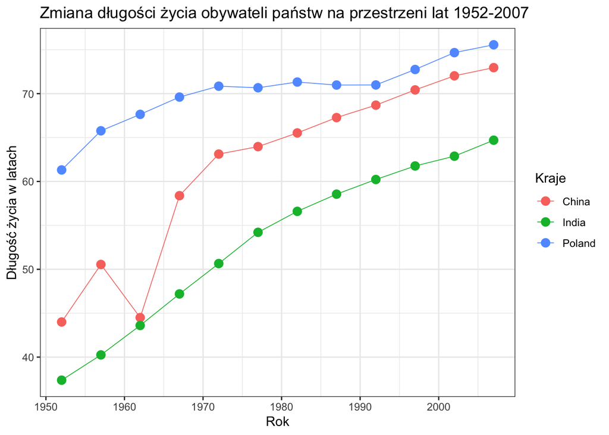

```r
library(ggplot2)

zmiana %>%
  ggplot(mapping = aes(x = rok, y = lifeExp,
                           col = country)) +
  geom_line(linewidth = 0.3) +
  geom_point(size = 3) +
  labs(title = "Zmiana długości życia obywateli państw na przestrzeni lat 1952-2007",
       x = "Rok",
       y = "Długość życia w latach",
       col = "Kraje") +
  theme_bw()
```

## Zadanie 8

Zadanie 8. należało zapoznać się z funkcją `set.seed()`. Jest to funkcja pozwalająca na uzyskanie powtarzających się rezultatów podczas pracy z kodem opartym na losowanych wartościach.

Następnie z wykorzystaniem funkcji `sample()` należało zasymulować rzut kostką sześcienną - rzucić ową kostką 2, 10, 50, 100 i 1000 razy.

```r
set.seed(1)

r2 <- sample(1:6, 2)
r10 <- sample(1:6, 10, TRUE)
r50 <- sample(1:6, 50, TRUE)
r100 <- sample(1:6, 100, TRUE)
r1000 <- sample(1:6, 1000, TRUE)
```

Kolejnym elementem było wykorzystanie funkcji `table()` do tego, by sprawdzić, jakie liczby uzyskano oraz funkcji `mean()`, by wyznaczyć średnią liczbę oczek w doświadczeniu.

```r
table(r2)
```

```
## r2
## 1 4
## 1 1
```

```r
table(r10)
```

```
## r10
## 1 2 3 5 6
## 2 2 3 2 1
```

```r
table(r50)
```

```
## r50
##  1  2  3  4  5  6
##  9 11  4  7  6 13
```

```r
table(r100)
```

```
## r100
##  1  2  3  4  5  6
## 18 17 18 17 15 15
```

```r
table(r1000)
```

```
## r1000
##   1   2   3   4   5   6
## 173 160 148 177 177 165
```

```r
mean(r2)
```

```
## [1] 2.5
```

```r
mean(r10)
```

```
## [1] 3.1
```

```r
mean(r50)
```

```
## [1] 3.58
```

```r
mean(r100)
```

```
## [1] 3.39
```

```r
mean(r1000)
```

```
## [1] 3.52
```

Druga część zadania skupiła się na symulacji Monte Carlo. Jest to metoda modelowania pewnych procesów poprzez wielokrotne przeprowadzanie losowych prób.

Powyższą metodę należało wykorzystać w następującym problemie: Dwa zespoły NBA, Chicago Bulls i NY Knicks, rozgrywają serię play-off składającą się z siedmiu meczów. Knicks są lepsi i mają 65% szans na wygranie każdego meczu. Rywalizacja toczy się do czterech zwycięstw. Przeprowadzić 10000 symulacji i sprawdzić jak często NY wygra rywalizację.

```r
set.seed(2)

symulacja <- function() {
  wynik <- sample(c("Knicks", "Bulls"), 7, replace = TRUE, prob = c(0.65, 0.35))
  if (sum(wynik == "Knicks") >= 4) {
    return(1)
  } else {
    return(0)
  }
}
wyniki <- replicate(10000, symulacja())

procent_wygranych <- sum(wyniki)/100
cat(procent_wygranych, "%")
```

```
## 79.73 %
```

## Zadanie 9

Zadanie dziewiąte zostało poświęcone dwóm ramkom danych `mammals` z pakietu `MASS`, która zawiera informacje o masie ciała i masie mózgu dla 62 wybranych zwierząt oraz `Animals2` z pakietu `robustbase`. W obu przypadkach nazwy wierszy identyfikują zwierzęta, a celem ćwiczenia jest zbadanie różnic między zwierzętami scharakteryzowanymi w obu zestawach danych.

Na samym początku wczytuję i wyświetlam powyższe zestawy danych.

```r
library(MASS)
library(robustbase)

mammals
```

|  | body | brain |
| --- | --- | --- |
| Arctic fox | 3.385 | 44.50 |
| Owl monkey | 0.480 | 15.50 |
| Mountain beaver | 1.350 | 8.10 |
| Cow | 465.000 | 423.00 |
| Grey wolf | 36.330 | 119.50 |
| Goat | 27.660 | 115.00 |
| Roe deer | 14.830 | 98.20 |
| Guinea pig | 1.040 | 5.50 |
| Verbet | 4.190 | 58.00 |
| Chinchilla | 0.425 | 6.40 |

[output cut: 52 more lines]

```r
Animals2
```

|  | body | brain |
| --- | --- | --- |
| Mountain beaver | 1.350 | 8.10 |
| Cow | 465.000 | 423.00 |
| Grey wolf | 36.330 | 119.50 |
| Goat | 27.660 | 115.00 |
| Guinea pig | 1.040 | 5.50 |
| Dipliodocus | 11700.000 | 50.00 |
| Asian elephant | 2547.000 | 4603.00 |
| Donkey | 187.100 | 419.00 |
| Horse | 521.000 | 655.00 |
| Potar monkey | 10.000 | 115.00 |

[output cut: 55 more lines]

Zadanie polega na wykonaniu 3 podpunktów:

1. Funkcja rownames() zwraca wektor nazw wierszy dla ramki danych, a funkcja intersect() wyznacza część wspólną dwóch zestawów, zwracając wektor ich wspólnych elementów. Korzystając z tych funkcji, skonstruować i wyświetlić wektor zwierzaki nazw zwierząt wspólnych dla obu ramek danych. Ile zwierząt zawiera ten zestaw?

```r
nazwy_mammals <- rownames(mammals)
nazwy_mammals
```

```
##  [1] "Arctic fox"                "Owl monkey"
##  [3] "Mountain beaver"           "Cow"
##  [5] "Grey wolf"                 "Goat"
##  [7] "Roe deer"                  "Guinea pig"
##  [9] "Verbet"                    "Chinchilla"
## [11] "Ground squirrel"           "Arctic ground squirrel"
## [13] "African giant pouched rat" "Lesser short-tailed shrew"
## [15] "Star-nosed mole"           "Nine-banded armadillo"
## [17] "Tree hyrax"                "N.A. opossum"
## [19] "Asian elephant"            "Big brown bat"
## [21] "Donkey"                    "Horse"
## [23] "European hedgehog"         "Patas monkey"
## [25] "Cat"                       "Galago"
## [27] "Genet"                     "Giraffe"
## [29] "Gorilla"                   "Grey seal"
```

[output cut: 16 more lines]

```r
nazwy_Animals2 <- rownames(Animals2)
nazwy_Animals2
```

```
##  [1] "Mountain beaver"           "Cow"
##  [3] "Grey wolf"                 "Goat"
##  [5] "Guinea pig"                "Dipliodocus"
##  [7] "Asian elephant"            "Donkey"
##  [9] "Horse"                     "Potar monkey"
## [11] "Cat"                       "Giraffe"
## [13] "Gorilla"                   "Human"
## [15] "African elephant"          "Triceratops"
## [17] "Rhesus monkey"             "Kangaroo"
## [19] "Golden hamster"            "Mouse"
## [21] "Rabbit"                    "Sheep"
## [23] "Jaguar"                    "Chimpanzee"
## [25] "Rat"                       "Brachiosaurus"
## [27] "Mole"                      "Pig"
## [29] "Artic fox"                 "Owl monkey"
```

[output cut: 18 more lines]

```r
zwierzaki <- intersect(nazwy_mammals, nazwy_Animals2)
zwierzaki
```

```
##  [1] "Owl monkey"                "Mountain beaver"
##  [3] "Cow"                       "Grey wolf"
##  [5] "Goat"                      "Roe deer"
##  [7] "Guinea pig"                "Verbet"
##  [9] "Chinchilla"                "Ground squirrel"
## [11] "African giant pouched rat" "Lesser short-tailed shrew"
## [13] "Star-nosed mole"           "Nine-banded armadillo"
## [15] "Tree hyrax"                "N.A. opossum"
## [17] "Asian elephant"            "Big brown bat"
## [19] "Donkey"                    "Horse"
## [21] "European hedgehog"         "Cat"
## [23] "Galago"                    "Genet"
## [25] "Giraffe"                   "Gorilla"
## [27] "Grey seal"                 "Rock hyrax-a"
## [29] "Human"                     "African elephant"
## [31] "Water opossum"             "Rhesus monkey"
## [33] "Kangaroo"                  "Yellow-bellied marmot"
## [35] "Golden hamster"            "Mouse"
## [37] "Little brown bat"          "Slow loris"
## [39] "Okapi"                     "Rabbit"
## [41] "Sheep"                     "Jaguar"
## [43] "Chimpanzee"                "Baboon"
## [45] "Desert hedgehog"           "Giant armadillo"
## [47] "Rock hyrax-b"              "Raccoon"
## [49] "Rat"                       "E. American mole"
## [51] "Musk shrew"                "Pig"
## [53] "Echidna"                   "Brazilian tapir"
## [55] "Tenrec"                    "Phalanger"
## [57] "Tree shrew"                "Red fox"
```

```r
length(zwierzaki)
```

```
## [1] 58
```

2. Funkcja setdiff() zwraca wektor elementów zawartych w jednym zbiorze, ale nie w drugim. Prosżę użyć tej funkcji, aby wyświetlić zwierzęta obecne w zestawie mammals, których nie ma w zestawie Animals2.

```r
setdiff(nazwy_mammals, nazwy_Animals2)
```

```
## [1] "Arctic fox"             "Arctic ground squirrel" "Patas monkey"
## [4] "Mole rat"
```

3. Użyć funkcji setdiff(), aby wyświetlić zwierzęta obecne w Animals2, które nie występują w zestawie mammals.

```r
setdiff(nazwy_Animals2, nazwy_mammals)
```

```
## [1] "Dipliodocus"           "Potar monkey"          "Triceratops"
## [4] "Brachiosaurus"         "Mole"                  "Artic fox"
## [7] "Artic ground squirrel"
```

## Zadanie 10

Ostatnie zadanie polega na wykonaniu kilku poleceń dotyczących poszczególnych rozkładów.

1. Użyć funkcji qnorm() by wyznaczyć 5% i 95% kwantyl dla rozkładu N(0,1).

```r
qnorm(c(0.05,0.95), 0, 1)
```

```
## [1] -1.644854  1.644854
```

2. Użyć funkcji qt(), by wyznaczyć 5% i 95% kwantyl dla rozkładu t-Studenta.

```r
qt(c(0.05,0.95), 1)
```

```
## [1] -6.313752  6.313752
```

3. Założyć, że liczba stopni swobody (parametr tego rozkładu) wynosi odpowiednio 1, 5, 10, 30, 50 i 1000. Jak uważasz, co ciekawego pokazują te przedziały?

```r
qt(c(0.05,0.95), 1)
```

```
## [1] -6.313752  6.313752
```

```r
qt(c(0.05,0.95), 5)
```

```
## [1] -2.015048  2.015048
```

```r
qt(c(0.05,0.95), 10)
```

```
## [1] -1.812461  1.812461
```

```r
qt(c(0.05,0.95), 30)
```

```
## [1] -1.697261  1.697261
```

```r
qt(c(0.05,0.95), 50)
```

```
## [1] -1.675905  1.675905
```

```r
qt(c(0.05,0.95), 1000)
```

```
## [1] -1.646379  1.646379
```

Na podstawie powyższych wyników możemy powiedzieć, że im większa ilość stopni swobody tym bardziej rozkład t-studenta jest zbliżony do rozkładu normalnego